# Project: Investigate a Dataset - [No-Show Appointments]

- Introduction
- Data Wrangling
- Exploratory Data Analysis
- Conclusions

## Introduction

### Dataset Description

This dataset gives us the records of patients and their appointments over a period of time. My analysis is to uncover the main contributing factors, to patients not attending their scheduled appointments.

Dataset columns and description

PatientId - Patient identification.

AppointmentID - Appointment Number

Gender - Gender of patient(Male or Female).

ScheduledDay - The day patient scheduled their appointment.

AppointmentDay - The day of actual visit to the doctor.

Age - Patient Age

Neighbourhood - Hospital location.

Scholarship - Whether or not the patient is enrolled in Brasilian welfare program Bolsa Família(0 is no & 1 is Yes).

Hipertension - Whether or not the patient has hypertension(0 is no & 1 is Yes).

Diabetes - Whether or not the patient has diabetes(0 is no & 1 is Yes).

Alcoholism - Whether or not the patient has alcoholism(0 is no & 1 is Yes).

Handicap - Whether or not the patient has handicaps(on scale of 0 to 4,where each number indicates the number of handicaps)

SMS_received = Whether or not the patient received SMS reminding patient of scheduled appointment(0 is no & 1 is Yes)

No-show = Whether or not the patient attended the scheduled appointment(Yes for missed appointment , No for did not miss appointment)

### Question(s) for Analysis

Question 1. Does the gender of the patient affect appointment attendance rate?

Question 2. Does receiving SMS's affect the appointment attendance rate?

Question 3. Is age a factor in determining appointment attendance?

Question 4. Is being on the Brasilian welfare program Bolsa Família contribute to appointment attendance?

Question 5. Does havinga handicap affect the attendance rate?

```python
pwd
```

```
'/home/workspace'
```

```python
cd Database_No_show_appointments
```

```
/home/workspace/Database_No_show_appointments
```

```python
!pip install seaborn
```

```python
import pandas as pd
import seaborn as sns
import matplotlib.pyplot as plt
% matplotlib inline
```

## Data Wrangling

### General Properties of No-Show Appointments Dataset

```python
#Load dataset and store as dataframe
medical_appointments_df = pd.read_csv('noshowappointments-kagglev2-may-2016.csv')

#Preview data to see if there any changes that need to be made
print(medical_appointments_df.info())
print(medical_appointments_df.head())
print(medical_appointments_df.isnull().sum().sum())
print(medical_appointments_df.duplicated().sum())
medical_appointments_df.describe()
```

```
<class 'pandas.core.frame.DataFrame'>
RangeIndex: 110527 entries, 0 to 110526
Data columns (total 14 columns):
PatientId         110527 non-null float64
AppointmentID     110527 non-null int64
Gender            110527 non-null object
ScheduledDay      110527 non-null object
AppointmentDay    110527 non-null object
Age               110527 non-null int64
Neighbourhood     110527 non-null object
Scholarship       110527 non-null int64
Hipertension      110527 non-null int64
Diabetes          110527 non-null int64
Alcoholism        110527 non-null int64
Handcap           110527 non-null int64
SMS_received      110527 non-null int64
No-show           110527 non-null object
dtypes: float64(1), int64(8), object(5)
memory usage: 11.8+ MB
None
      PatientId  AppointmentID Gender          ScheduledDay  \
0  2.987250e+13        5642903      F  2016-04-29T18:38:08Z
1  5.589978e+14        5642503      M  2016-04-29T16:08:27Z
2  4.262962e+12        5642549      F  2016-04-29T16:19:04Z
3  8.679512e+11        5642828      F  2016-04-29T17:29:31Z
4  8.841186e+12        5642494      F  2016-04-29T16:07:23Z

         AppointmentDay  Age      Neighbourhood  Scholarship  Hipertension  \
0  2016-04-29T00:00:00Z   62    JARDIM DA PENHA            0             1
1  2016-04-29T00:00:00Z   56    JARDIM DA PENHA            0             0
2  2016-04-29T00:00:00Z   62      MATA DA PRAIA            0             0
3  2016-04-29T00:00:00Z    8  PONTAL DE CAMBURI            0             0
4  2016-04-29T00:00:00Z   56    JARDIM DA PENHA            0             1

   Diabetes  Alcoholism  Handcap  SMS_received No-show
0         0           0        0             0      No
1         0           0        0             0      No
2         0           0        0             0      No
3         0           0        0             0      No
4         1           0        0             0      No
0
0
```

|  | PatientId | AppointmentID | Age | Scholarship | Hipertension | Diabetes | Alcoholism | Handcap | SMS_received |
| --- | --- | --- | --- | --- | --- | --- | --- | --- | --- |
| count | 1.105270e+05 | 1.105270e+05 | 110527.000000 | 110527.000000 | 110527.000000 | 110527.000000 | 110527.000000 | 110527.000000 | 110527.000000 |
| mean | 1.474963e+14 | 5.675305e+06 | 37.088874 | 0.098266 | 0.197246 | 0.071865 | 0.030400 | 0.022248 | 0.321026 |
| std | 2.560949e+14 | 7.129575e+04 | 23.110205 | 0.297675 | 0.397921 | 0.258265 | 0.171686 | 0.161543 | 0.466873 |
| min | 3.921784e+04 | 5.030230e+06 | -1.000000 | 0.000000 | 0.000000 | 0.000000 | 0.000000 | 0.000000 | 0.000000 |
| 25% | 4.172614e+12 | 5.640286e+06 | 18.000000 | 0.000000 | 0.000000 | 0.000000 | 0.000000 | 0.000000 | 0.000000 |
| 50% | 3.173184e+13 | 5.680573e+06 | 37.000000 | 0.000000 | 0.000000 | 0.000000 | 0.000000 | 0.000000 | 0.000000 |
| 75% | 9.439172e+13 | 5.725524e+06 | 55.000000 | 0.000000 | 0.000000 | 0.000000 | 0.000000 | 0.000000 | 1.000000 |
| max | 9.999816e+14 | 5.790484e+06 | 115.000000 | 1.000000 | 1.000000 | 1.000000 | 1.000000 | 4.000000 | 1.000000 |

### Data Cleaning

After assesing the dataset, I have no columns with NaN values and also there are no duplicated rows. There are however some columns that need to be renamed and others that do not have the appropriate data type. Column age also has some values that are not possible, those need to be dropped.

```python
#dropping non-essential columns to my analysis
medical_appointments_df.drop(columns=['PatientId','AppointmentID'],inplace=True)
```

```python
#Confirm changes
medical_appointments_df.info()
```

```
<class 'pandas.core.frame.DataFrame'>
RangeIndex: 110527 entries, 0 to 110526
Data columns (total 12 columns):
Gender            110527 non-null object
ScheduledDay      110527 non-null object
AppointmentDay    110527 non-null object
Age               110527 non-null int64
Neighbourhood     110527 non-null object
Scholarship       110527 non-null int64
Hipertension      110527 non-null int64
Diabetes          110527 non-null int64
Alcoholism        110527 non-null int64
Handcap           110527 non-null int64
SMS_received      110527 non-null int64
No-show           110527 non-null object
dtypes: int64(7), object(5)
memory usage: 10.1+ MB
```

```python
#Rename misspelled columns and assign appropriate names to other columns and confirm changes
medical_appointments_df = medical_appointments_df.rename(columns={"Hipertension": "Hypertension",
                                        "Neighbourhood": "Hospital_Location",
                                        "Handcap": "Handicap",
                                        "No-show": "Missed_Scheduled_Appointment",
                                        "ScheduledDay": "Scheduled_Day_Of_Hospital_Visit",
                                        "AppointmentDay": "Actual_Day_Of_Hospital_Visit",
                                        "Scholarship": "Welfare_Program_Status"})
```

```python
#Confirm changes
medical_appointments_df.info()
```

```
<class 'pandas.core.frame.DataFrame'>
RangeIndex: 110527 entries, 0 to 110526
Data columns (total 12 columns):
Gender                             110527 non-null object
Scheduled_Day_Of_Hospital_Visit    110527 non-null object
Actual_Day_Of_Hospital_Visit       110527 non-null object
Age                                110527 non-null int64
Hospital_Location                  110527 non-null object
Welfare_Program_Status             110527 non-null int64
Hypertension                       110527 non-null int64
Diabetes                           110527 non-null int64
Alcoholism                         110527 non-null int64
Handicap                           110527 non-null int64
SMS_received                       110527 non-null int64
Missed_Scheduled_Appointment       110527 non-null object
dtypes: int64(7), object(5)
memory usage: 10.1+ MB
```

```python
#Convert columns with dates to datetime datatype
medical_appointments_df['Scheduled_Day_Of_Hospital_Visit'] = pd.to_datetime(medical_appointments_df['Scheduled_Day_Of_Hospital_Visit'])
medical_appointments_df['Actual_Day_Of_Hospital_Visit'] = pd.to_datetime(medical_appointments_df['Actual_Day_Of_Hospital_Visit'])
```

```python
#Confirm changes
medical_appointments_df.info()
```

```
<class 'pandas.core.frame.DataFrame'>
RangeIndex: 110527 entries, 0 to 110526
Data columns (total 12 columns):
Gender                             110527 non-null object
Scheduled_Day_Of_Hospital_Visit    110527 non-null datetime64[ns]
Actual_Day_Of_Hospital_Visit       110527 non-null datetime64[ns]
Age                                110527 non-null int64
Hospital_Location                  110527 non-null object
Welfare_Program_Status             110527 non-null int64
Hypertension                       110527 non-null int64
Diabetes                           110527 non-null int64
Alcoholism                         110527 non-null int64
Handicap                           110527 non-null int64
SMS_received                       110527 non-null int64
Missed_Scheduled_Appointment       110527 non-null object
dtypes: datetime64[ns](2), int64(7), object(3)
memory usage: 10.1+ MB
```

```python
#Convert yes and no values of column Missed_Scheduled_Appointment to binary ad cast type to int.
medical_appointments_df['Missed_Scheduled_Appointment']=medical_appointments_df['Missed_Scheduled_Appointment'].map({'Yes':0,'No':1})
medical_appointments_df['Missed_Scheduled_Appointment']=medical_appointments_df['Missed_Scheduled_Appointment'].astype(int);
```

```python
#Confirm changes
medical_appointments_df.info()
```

```
<class 'pandas.core.frame.DataFrame'>
RangeIndex: 110527 entries, 0 to 110526
Data columns (total 12 columns):
Gender                             110527 non-null object
Scheduled_Day_Of_Hospital_Visit    110527 non-null datetime64[ns]
Actual_Day_Of_Hospital_Visit       110527 non-null datetime64[ns]
Age                                110527 non-null int64
Hospital_Location                  110527 non-null object
Welfare_Program_Status             110527 non-null int64
Hypertension                       110527 non-null int64
Diabetes                           110527 non-null int64
Alcoholism                         110527 non-null int64
Handicap                           110527 non-null int64
SMS_received                       110527 non-null int64
Missed_Scheduled_Appointment       110527 non-null int64
dtypes: datetime64[ns](2), int64(8), object(2)
memory usage: 10.1+ MB
```

```python
#Drop rows with negative value in column Age since we cannot have negative ages
medical_appointments_df.drop(medical_appointments_df[medical_appointments_df.Age == -1].index,inplace=True)
```

```python
#Confirm if rows have been dropped
medical_appointments_df.query("Age<0")
```

|  | Gender | Scheduled_Day_Of_Hospital_Visit | Actual_Day_Of_Hospital_Visit | Age | Hospital_Location | Welfare_Program_Status | Hypertension | Diabetes | Alcoholism | Handicap | SMS_received | Missed_Scheduled_Appointment |
| --- | --- | --- | --- | --- | --- | --- | --- | --- | --- | --- | --- | --- |

```python
#Create a new column age_group based on the values in the column age
def categorize_age(row):
    if 0 <= row['Age'] <= 12:
        value = 'Child'
    elif 12 < row['Age'] <= 20:
        value = 'Adolescent'
    elif 20 < row['Age'] <= 60:
        value = 'Adult'
    else:
        value = 'Senior Citizen'
    return value
medical_appointments_df['Age_Group'] = medical_appointments_df.apply(lambda row: categorize_age(row),axis=1)
```

```python
#Confirm changes
medical_appointments_df.head()
```

|  | Gender | Scheduled_Day_Of_Hospital_Visit | Actual_Day_Of_Hospital_Visit | Age | Hospital_Location | Welfare_Program_Status | Hypertension | Diabetes | Alcoholism | Handicap | SMS_received | Missed_Scheduled_Appointment | Age_Group |
| --- | --- | --- | --- | --- | --- | --- | --- | --- | --- | --- | --- | --- | --- |
| 0 | F | 2016-04-29 18:38:08 | 2016-04-29 | 62 | JARDIM DA PENHA | 0 | 1 | 0 | 0 | 0 | 0 | 1 | Senior Citizen |
| 1 | M | 2016-04-29 16:08:27 | 2016-04-29 | 56 | JARDIM DA PENHA | 0 | 0 | 0 | 0 | 0 | 0 | 1 | Adult |
| 2 | F | 2016-04-29 16:19:04 | 2016-04-29 | 62 | MATA DA PRAIA | 0 | 0 | 0 | 0 | 0 | 0 | 1 | Senior Citizen |
| 3 | F | 2016-04-29 17:29:31 | 2016-04-29 | 8 | PONTAL DE CAMBURI | 0 | 0 | 0 | 0 | 0 | 0 | 1 | Child |
| 4 | F | 2016-04-29 16:07:23 | 2016-04-29 | 56 | JARDIM DA PENHA | 0 | 1 | 1 | 0 | 0 | 0 | 1 | Adult |

## Exploratory Data Analysis

### Does the gender of the patient affect appointment attendance rate?

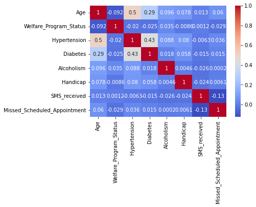

```python
#Visualize correlation if any between columns in the dataframe
sns.heatmap(medical_appointments_df.corr(), annot = True, cmap= 'coolwarm');
```

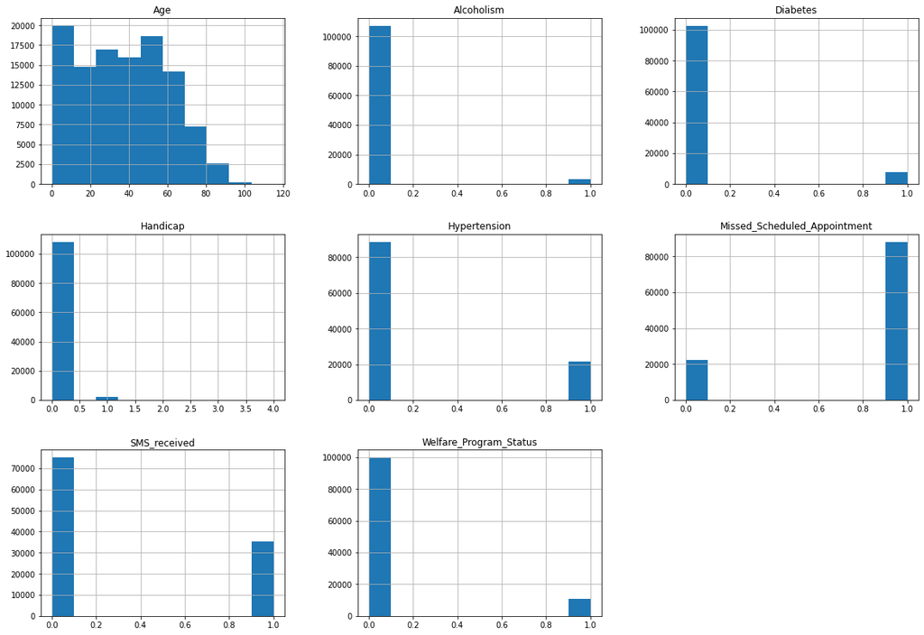

```python
#Visualize entire dataframe first to show skew
medical_appointments_df.hist(figsize=(20,14));
```

```python
#Get the number of people who showed up for their appointments
medical_appointments_df['Missed_Scheduled_Appointment'].value_counts()
```

```
1    88207
0    22319
Name: Missed_Scheduled_Appointment, dtype: int64
```

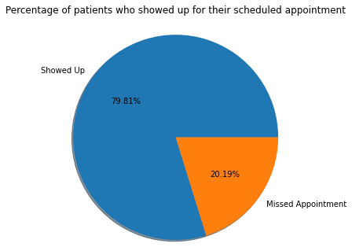

```python
#Piechart showing percentage of patients who missed their appointments
label_names = ["Showed Up", "Missed Appointment"]
appointment_data = [medical_appointments_df.loc[(medical_appointments_df['Missed_Scheduled_Appointment'] == 1)].count()[0], medical_appointments_df.loc[(medical_appointments_df['Missed_Scheduled_Appointment'] == 0)].count()[0]]
plt.pie(appointment_data,radius=1.5,shadow=True ,labels = label_names ,autopct='%0.2f%%')
plt.title("Percentage of patients who showed up for their scheduled appointment",y=1.2);
```

```python
#Function to plot percentage of the various columns against the Missed_Scheduled_Appointment column
def get_percentage(df,x_col,hue_col,title):
    df1 = medical_appointments_df.groupby(x_col)[hue_col].value_counts(normalize=True)
    df1 = df1.mul(100)
    df1 = df1.rename('percent').reset_index()
    g = sns.catplot(x=x_col,y='percent',hue=hue_col,kind='bar',data=df1).set(title=title)
    g.ax.set_ylim(0,100)
    for p in g.ax.patches:
        txt = str(p.get_height().round(2)) + '%'
        txt_x = p.get_x()
        txt_y = p.get_height()
        g.ax.text(txt_x,txt_y,txt)
```

```python
#Show number of male and female patients who missed their appointments
medical_appointments_df.groupby(['Missed_Scheduled_Appointment','Gender'])['Gender'].count().unstack()
```

| Gender Missed_Scheduled_Appointment | F | M |
| --- | --- | --- |
| 0 | 14594 | 7725 |
| 1 | 57245 | 30962 |

This table shows the number of women and men that missed their appointments

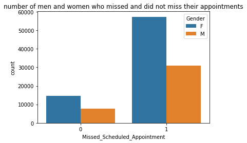

```python
#Count plot to show number of men and women who missed and did not miss their appointments
sns.countplot(x='Missed_Scheduled_Appointment', hue='Gender',data=medical_appointments_df).set(title="number of men and women who missed and did not miss their appointments");
```

the plot shows the count of males and females who missed and who did not miss their appointments.

```python
#Proportion of males and females that did not miss their appointments
medical_appointments_df.groupby('Gender')['Missed_Scheduled_Appointment'].value_counts(normalize=True).unstack('Missed_Scheduled_Appointment')
```

| Missed_Scheduled_Appointment Gender | 0 | 1 |
| --- | --- | --- |
| F | 0.203149 | 0.796851 |
| M | 0.199679 | 0.800321 |

This table shows the proportion of women to men that missed their appointments

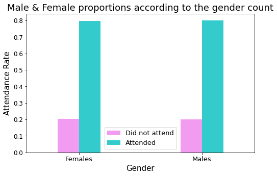

```python
#Bar plot to show proportion of male and female that did not miss their appointments
gender = medical_appointments_df.groupby('Gender')['Missed_Scheduled_Appointment'].value_counts(normalize=True).unstack('Missed_Scheduled_Appointment')
gender.plot(kind = "bar",
                       rot = 0,
                       width = 0.35,
                       color=["violet","c"],
                       alpha = 0.8,
                       fontsize = 12,
                       figsize=(8,5)
                         )
plt.ylabel("Attendance Rate",fontsize=15, color="k")
plt.xlabel("Gender",fontsize=15, color="k")
plt.title("Male & Female proportions according to the gender count",fontsize=18, color="k")
labels = ["Females","Males"]
plt.xticks(range(len(labels)),labels, fontsize=13);
plt.legend(["Did not attend","Attended"],fontsize=13);
```

This bar plot shows the rate at which both men and women attended their appointments

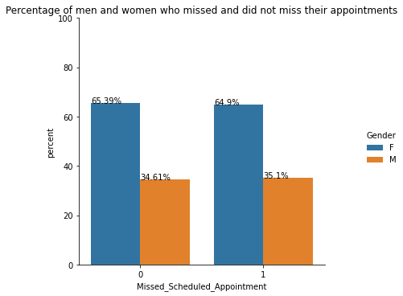

```python
#Seaborn plot to show percentage of men and women who missed and did not miss their appointments
get_percentage(medical_appointments_df,'Missed_Scheduled_Appointment','Gender',"Percentage of men and women who missed and did not miss their appointments");
```

The above visualization shows the percentge of men and women who missed and did not miss their appointments

### Does receiving SMS's affect the appointment attendance rate?

```python
#Show number of patients who received SMS's and whether or not they missed their appointments
medical_appointments_df.groupby(['Missed_Scheduled_Appointment','SMS_received'])['SMS_received'].count().unstack()
```

| SMS_received Missed_Scheduled_Appointment | 0 | 1 |
| --- | --- | --- |
| 0 | 12535 | 9784 |
| 1 | 62509 | 25698 |

The table shows the number of patients who received SMS's and whether or not they missed their appointments

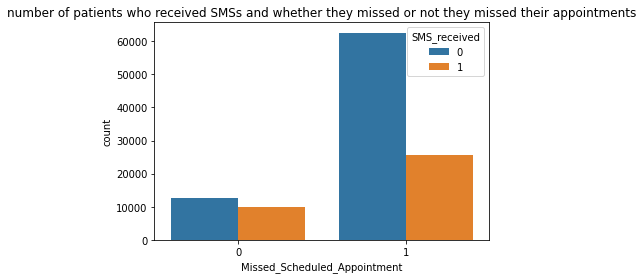

```python
#Countplot to show number of patients who received SMSs and whether they missed or not they missed their appointments
sns.countplot(x='Missed_Scheduled_Appointment', hue='SMS_received',data=medical_appointments_df).set(title="number of patients who received SMSs and whether they missed or not they missed their appointments");
```

the plot shows the number of patients who received SMSs and whether they missed or not they missed their appointments

```python
#Proportion of patients that received SMS's and did not miss their appointments
medical_appointments_df.groupby('SMS_received')['Missed_Scheduled_Appointment'].value_counts(normalize=True).unstack('Missed_Scheduled_Appointment')
```

| Missed_Scheduled_Appointment SMS_received | 0 | 1 |
| --- | --- | --- |
| 0 | 0.167035 | 0.832965 |
| 1 | 0.275745 | 0.724255 |

Table above shows the proportion of patients that received SMS's and did not miss their appointments

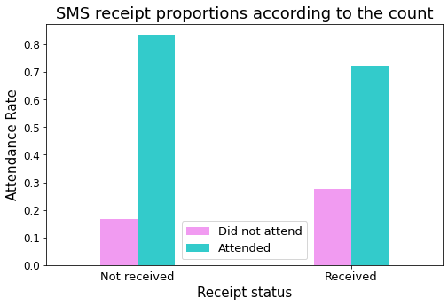

```python
#Bar plot to show proportion of patients that received SMS's and did not miss their appointments
sms = medical_appointments_df.groupby('SMS_received')['Missed_Scheduled_Appointment'].value_counts(normalize=True).unstack('Missed_Scheduled_Appointment')
sms.plot(kind = "bar",
                       rot = 0,
                       width = 0.35,
                       color=["violet","c"],
                       alpha = 0.8,
                       fontsize = 12,
                       figsize=(8,5)
                         )
plt.ylabel("Attendance Rate",fontsize=15, color="k")
plt.xlabel("Receipt status",fontsize=15, color="k")
plt.title("SMS receipt proportions according to the count",fontsize=18, color="k")
labels = ["Not received","Received"]
plt.xticks(range(len(labels)),labels, fontsize=13);
plt.legend(["Did not attend","Attended"],fontsize=13);
```

Graphic above shows the attendance rate of patients who received SMS's and those that did not.

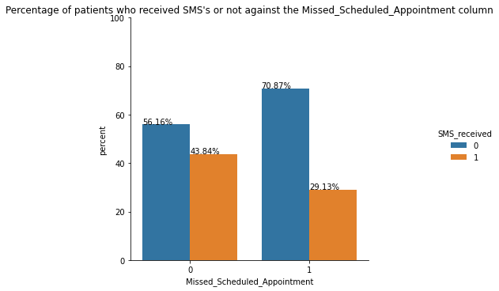

```python
#Seaborn plot to show percentage of patients who received SMS's or not against the Missed_Scheduled_Appointment column
get_percentage(medical_appointments_df,'Missed_Scheduled_Appointment','SMS_received',"Percentage of patients who received SMS's or not against the Missed_Scheduled_Appointment column");
```

Visualization above shows the percentage of patients who received SMS's and those that did not and their attendance rate

### Is age a factor in determining appointment attendance?

```python
#Show the number of patients in the different age groups and their appointment status
medical_appointments_df.groupby(['Missed_Scheduled_Appointment','Age_Group'])['Age_Group'].count().unstack()
```

| Age_Group Missed_Scheduled_Appointment | Adolescent | Adult | Child | Senior Citizen |
| --- | --- | --- | --- | --- |
| 0 | 2789 | 12217 | 4307 | 3006 |
| 1 | 8023 | 46699 | 16729 | 16756 |

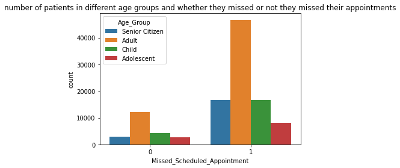

```python
#Countplot to show number of patients in different age groups and whether they missed or not they missed their appointments
sns.countplot(x='Missed_Scheduled_Appointment', hue='Age_Group',data=medical_appointments_df).set(title="number of patients in different age groups and whether they missed or not they missed their appointments");
```

```python
#Proportion of pateints in different age groups that did not miss their appointments
medical_appointments_df.groupby('Age_Group')['Missed_Scheduled_Appointment'].value_counts(normalize=True).unstack('Missed_Scheduled_Appointment')
```

| Missed_Scheduled_Appointment Age_Group | 0 | 1 |
| --- | --- | --- |
| Adolescent | 0.257954 | 0.742046 |
| Adult | 0.207363 | 0.792637 |
| Child | 0.204744 | 0.795256 |
| Senior Citizen | 0.152110 | 0.847890 |

Table shows the proportion of pateints in different age groups that did not miss or missed their appointments

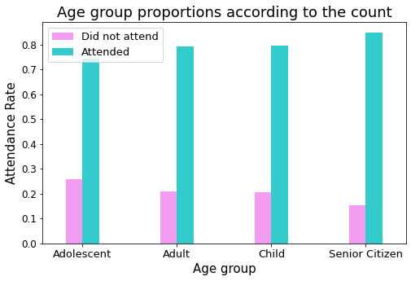

```python
#Bar plot to show proportion of pateints in different age groups that did not miss their appointments
age_group = medical_appointments_df.groupby('Age_Group')['Missed_Scheduled_Appointment'].value_counts(normalize=True).unstack('Missed_Scheduled_Appointment')
age_group.plot(kind = "bar",
                       rot = 0,
                       width = 0.35,
                       color=["violet","c"],
                       alpha = 0.8,
                       fontsize = 12,
                       figsize=(8,5)
                         )
plt.ylabel("Attendance Rate",fontsize=15, color="k")
plt.xlabel("Age group",fontsize=15, color="k")
plt.title("Age group proportions according to the count",fontsize=18, color="k")
plt.xticks(fontsize=13);
plt.legend(["Did not attend","Attended"],fontsize=13);
```

The graphic above allows us to visualize the proportions of the patients in the various age groups and their attendance rate

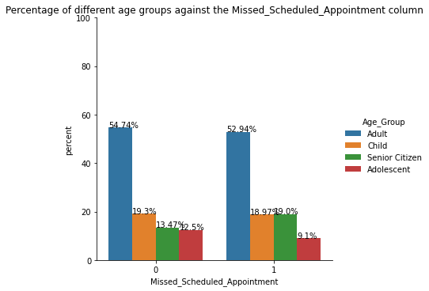

```python
#Seaborn plot to show the percentage of different age groups against the Missed_Scheduled_Appointment column
get_percentage(medical_appointments_df,'Missed_Scheduled_Appointment','Age_Group',"Percentage of different age groups against the Missed_Scheduled_Appointment column");
```

This helps us visually represent the percentage of different age groups against the Missed_Scheduled_Appointment column

### Is being on the Brasilian welfare program Bolsa Família contribute to appointment attendance?

```python
#Show the number of patients on the Bolsa Família welfare and their appointment status
medical_appointments_df.groupby(['Missed_Scheduled_Appointment','Welfare_Program_Status'])['Welfare_Program_Status'].count().unstack()
```

| Welfare_Program_Status Missed_Scheduled_Appointment | 0 | 1 |
| --- | --- | --- |
| 0 | 19741 | 2578 |
| 1 | 79924 | 8283 |

This represents number of patients on the Bolsa Família welfare and their appointment status in a tabular form

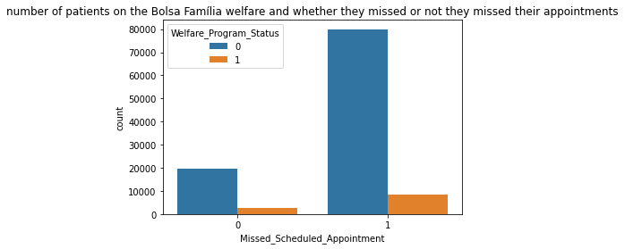

```python
#Countplot to show number of patients on the Bolsa Família welfare and whether they missed or not they missed their appointments
sns.countplot(x='Missed_Scheduled_Appointment', hue='Welfare_Program_Status',data=medical_appointments_df).set(title="number of patients on the Bolsa Família welfare and whether they missed or not they missed their appointments");
```

This represents visually the number of patients on the Bolsa Família welfare and whether they missed or not they missed their appointments

```python
#Proportion of patients on welfare that did not miss their appointments
medical_appointments_df.groupby('Welfare_Program_Status')['Missed_Scheduled_Appointment'].value_counts(normalize=True).unstack('Missed_Scheduled_Appointment')
```

| Missed_Scheduled_Appointment Welfare_Program_Status | 0 | 1 |
| --- | --- | --- |
| 0 | 0.198074 | 0.801926 |
| 1 | 0.237363 | 0.762637 |

Table represents the proportion of patients on welfare that did not miss their appointments

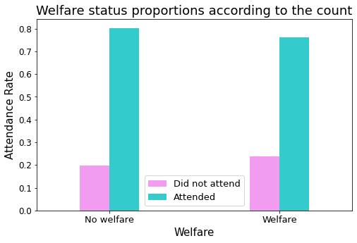

```python
#Bar plot to show proportion of patients on welfare that did not miss their appointments
welfare = medical_appointments_df.groupby('Welfare_Program_Status')['Missed_Scheduled_Appointment'].value_counts(normalize=True).unstack('Missed_Scheduled_Appointment')
welfare.plot(kind = "bar",
                       rot = 0,
                       width = 0.35,
                       color=["violet","c"],
                       alpha = 0.8,
                       fontsize = 12,
                       figsize=(8,5)
                         )
plt.ylabel("Attendance Rate",fontsize=15, color="k")
plt.xlabel("Welfare",fontsize=15, color="k")
plt.title("Welfare status proportions according to the count",fontsize=18, color="k")
labels = ["No welfare","Welfare"]
plt.xticks(range(len(labels)),labels, fontsize=13);
plt.legend(["Did not attend","Attended"],fontsize=13);
```

Visually represent the proportion of patients on welfare that did not miss their appointments

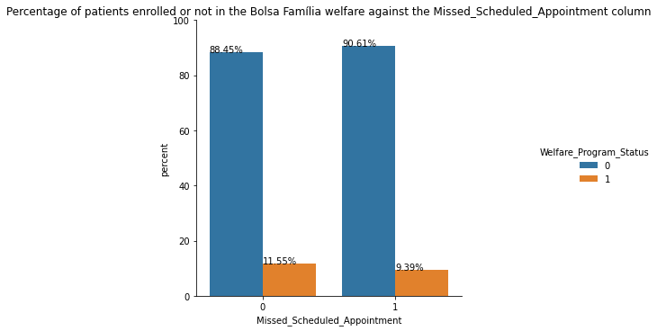

```python
#Seaborn plot to show the percentage of patients enrolled or not in the Bolsa Família welfare against the Missed_Scheduled_Appointment column
get_percentage(medical_appointments_df,'Missed_Scheduled_Appointment','Welfare_Program_Status',"Percentage of patients enrolled or not in the Bolsa Família welfare against the Missed_Scheduled_Appointment column");
```

This graphic above helps us to visually represent the percentage of patients enrolled or not in the Bolsa Família welfare against the Missed_Scheduled_Appointment column

### Is being handicapped affect appointment attendance?

```python
#Show the number of patients who are handicapped and their appointment status
medical_appointments_df.groupby(['Missed_Scheduled_Appointment','Handicap'])['Handicap'].count().unstack()
```

| Handicap Missed_Scheduled_Appointment | 0 | 1 | 2 | 3 | 4 |
| --- | --- | --- | --- | --- | --- |
| 0 | 21912 | 366 | 37 | 3 | 1 |
| 1 | 86373 | 1676 | 146 | 10 | 2 |

Table displays the number of patients who are handicapped and their appointment status

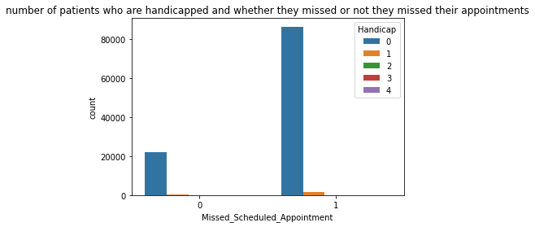

```python
#Countplot to show number of patients who are handicapped and whether they missed or not they missed their appointments
sns.countplot(x='Missed_Scheduled_Appointment', hue='Handicap',data=medical_appointments_df).set(title="number of patients who are handicapped and whether they missed or not they missed their appointments");
```

Plot above shows the number of patients who are handicapped and whether they missed or not they missed their appointments

```python
#Proportion of handicapped patients that did not miss their appointments
medical_appointments_df.groupby('Handicap')['Missed_Scheduled_Appointment'].value_counts(normalize=True).unstack('Missed_Scheduled_Appointment')
```

| Missed_Scheduled_Appointment Handicap | 0 | 1 |
| --- | --- | --- |
| 0 | 0.202355 | 0.797645 |
| 1 | 0.179236 | 0.820764 |
| 2 | 0.202186 | 0.797814 |
| 3 | 0.230769 | 0.769231 |
| 4 | 0.333333 | 0.666667 |

Table above shows the proportion of handicapped patients that did not miss their appointments

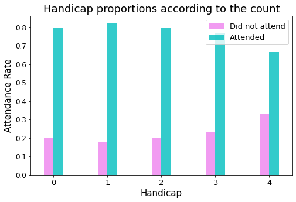

```python
#Bar plot to show proportion of handicapped patients that did not miss their appointments
welfare = medical_appointments_df.groupby('Handicap')['Missed_Scheduled_Appointment'].value_counts(normalize=True).unstack('Missed_Scheduled_Appointment')
welfare.plot(kind = "bar",
                       rot = 0,
                       width = 0.35,
                       color=["violet","c"],
                       alpha = 0.8,
                       fontsize = 12,
                       figsize=(8,5)
                         )
plt.ylabel("Attendance Rate",fontsize=15, color="k")
plt.xlabel("Handicap",fontsize=15, color="k")
plt.title("Handicap proportions according to the count",fontsize=18, color="k")
plt.xticks(fontsize=13);
plt.legend(["Did not attend","Attended"],fontsize=13);
```

Plot helps us show proportion of handicapped patients that did not miss their appointments visually

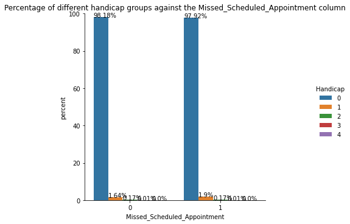

```python
#Seaborn plot to show the percentage of different handicap groups against the Missed_Scheduled_Appointment column
get_percentage(medical_appointments_df,'Missed_Scheduled_Appointment','Handicap',"Percentage of different handicap groups against the Missed_Scheduled_Appointment column");
```

Visualize the percentage of different handicap groups against the Missed_Scheduled_Appointment column

## Conclusions

Question 1. Does the gender of the patient affect appointment attendance rate?

Answer Gender has no correlation to patients attending their appointments. The percentage of both men and women missing appointments is almost the same.

Question 4. Is being on the Brasilian welfare program Bolsa Família contribute to appointment attendance?

Question 5. Does having a handicap affect the attendance rate?

Answer Handicap does not have a direct correlation with attendance rates.

Limitation I would have liked for there to be a row stating patient locations from the hospital locations. This would have given me additional insight as to why pateints might miss their appointments by being able to calculate the distance needed to travel between locations.

## Submitting your Project

```python
from subprocess import call
call(['python', '-m', 'nbconvert', 'Investigate_a_Dataset.ipynb'])
```

```
255
```